# Introduction to Conjugate Priors

Omkar Shetty

18/06/2020

## Introduction

This note book is based on material created for a presentation on Bayesian Analysis Techniques. The objective is to walk a would-be Bayesian through a toy example solved using Conjugate Priors. A secondary goal is to highlight potential drawbacks and why ultmately an MCMC based analysis is required for most real world examples.

This example will use a beta-binomial framework.

## Problem Definition

Product availability is a fundamental problem in the retail world and organizations use a multitude of solutions to predict/detect on-shelf availability including predictive models and computer vision. While this section will not deal with predicting availability directly, we will take a stab at understanding the true underlying availability for a toy example based on some simulated data.

## Binomial and Beta Distributions - a quick recap

For this example, we will use a beta prior and a binomial likelihood that lend themselves well to such a problem and coincidentally happen to fit the conjugate prior framework as well !

### Beta Distribution

A beta distribution is commonly used as a prior for probabilities and proportions, because of two main reasons : - values range between 0 and 1 - very flexible; can be used to express a wide range of beliefs

A few examples of beta priors are given below:

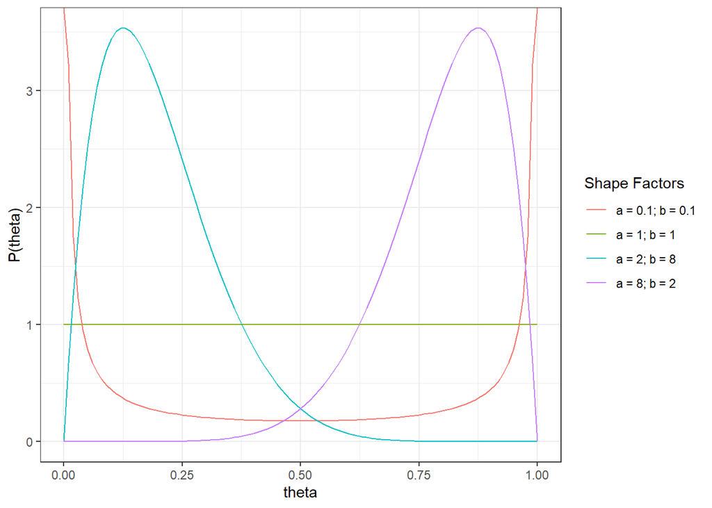

The functional form for a beta distribution is given by :

$$beta(a,b) = \frac{\theta^{a-1}(1 - \theta)^{b-1} }{\beta(a,b)}$$
where
$$a, b > 0$$
Here a and b are called the shape factors and the $\beta$(a,b) is the beta function which is used as a normalising constant.

We will be using a beta distribution to express our prior belief of what the true availability % of SKUs is.

### Binomial Distribution

A binomial distribution is often used to express the distribution of the probability of getting Z successes from N independent trials, where each trial can have a success/failure outcome. For the availability problem, we can construct each observation as a success/failure outcome, where a successful observation would imply that the product was available throughout the day and a unsuccessful observation would be one where the SKU was not available for purchase at some time throughout the day.

$$binomial(y|N,p) = \frac{N!}{y!(N-y)!}\cdot p^y \cdot (1-p)^{N-y} = {{N}\choose{y}} \cdot p^y \cdot (1-p)^{N-y}$$

## Specifying the Prior and Likelihood

In this section, we specify the priors and the likelihood function for the availability example.

### Likelihood

The goal here is to understand the true proprtion of products that are available in a store. For the data, lets assume 80 unique products (randomly selected) were monitored throughout the day - and any product that wasn’t available on the shelf at any time during the day is classified as unavailable. In this example, lets assume 73/80 SKUs were available all throughout the day. (as a reference most big-box retailers can maintain a 90% availability or higher).

Using the form above, a binomial distribution is used to represent this trial - with each available SKU representing a success (given by 1) and missing SKUs defined by a 0.

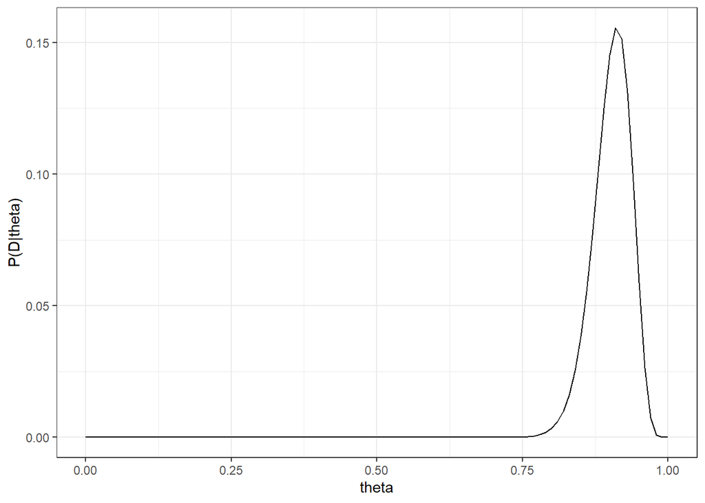

```r
#define a likelihood function
likelihood <- function(n,y,theta){
  return(choose(n,y)*(theta^y)*((1-theta)^(n-y)))
}


#Binomial distribution for the 80 observed SKUs
lik <- data.frame(theta = theta, likelihood = likelihood(80,73,theta))

ggplot(data = lik, aes(x = theta, y = likelihood)) + geom_line(col = 'black') +
  labs(x = 'theta', y = 'P(D|theta)') + theme_bw()
```

### What is the best prior to go with ?

Usually, the aspect of Bayesian analysis that most concerns newer entrants is the bias associated with selecting a prior. To highlight the impact of priors, we will use two options, -a. a flat prior (analogous to a uniform distribution) -b. a strongly pessimistic prior with an expected average of ~ 20%

As an illustration, the two priors are plotted below :

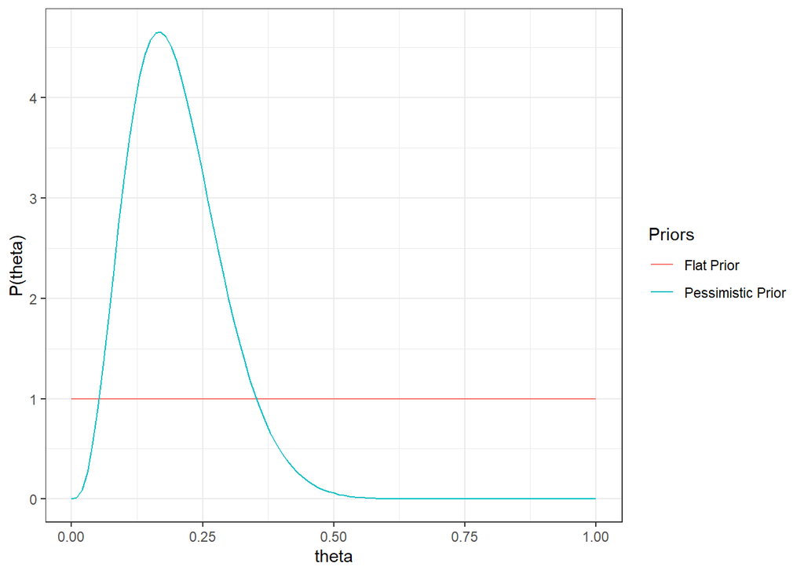

```r
theta <- seq(0,1,0.01)

ggplot() +
  geom_line(aes(x = theta, y = dbeta(theta, 1, 1), col = 'Flat Prior')) +
  geom_line(aes(x = theta, y = dbeta(theta, 4, 16), col = 'Pessimistic Prior')) +
  labs(x = 'theta', y = 'P(theta)', colour = 'Priors') +
  theme_bw()
```

## Calculating the Posterior